# The Department of Defense and its Correspondence Relationship with Legislators

PS 699: Independent Study (Spring 2020)

Fatima Ali

# Data

Altogether we have 7635 letters received by the Department of Defense that are marked as “congressional” from 2007-2017. All of these letters are from Members of the U.S. Congress. Note: During my independent study, I handcoded approzimately 3,492 letters from a variety of Department of Defense agencise. Unfortunately, we were not able to implement these observations into the final data set. Thus, observations that are missing a Policy Type Category have a current Type of NA.

```r
load(here("data/all_contacts.RData"))
# one obs per member per letter for all agencies
d <- all_contacts %>% filter(str_detect(agency, "DOD")) %>% filter(year <2018, year >2006) # 2007-2017 Data Points
```

# A Potential Outlier

In this analysis, Senator Grassley (R-IA) is considered to be an outlier. He wrote 188 letters to the Department of Defense, the most out of any other members of congress. However, he was never a part of any committee that actively work for the Department of Defense. Although at this point, we are unable to see what are the policy categories of the letters he wrote to the Department of Defense, based off of the hand-coding I did, Grassley wrote a majority of his letters on behalf of constituents, specifically for Veterans in Iowa. On further analysis, Grassley’s campaign has largely been based on providing veterans in Iowa opportunities to present their legacy to other residents in Iowa and the US, and more within the realm of congressional agencies, aid with ensuring that veterans receive their benefits after retiring or being discharged from the military. These benefits include disability compensation, education programs, health benefits, and more. A majority of these concerns would be best addressed via the Department of Veteran Affairs versus most of the Department of Defense agencies, however, many of the issues, such as Military Pay complaints as well as sexual harrassment allegations can indeed be addressed with the Department of Defense agencies, such as the Department of Defense and Accounting Service (DFAS) as well as the Office of the Inspector General, U.S. Department of Defense (DOD_OIG). Thus, at this time, I am not considering Senator Grassley to be an outlier in my analysis.

```r
dc <- all_contacts %>% filter(str_detect(agency, "DOD")) %>% filter(year <2018, year >2006) %>% filter(last_name == "GRASSLEY")

dc %>% count(bioname,party, TYPE, cqlabel, sort = T) %>% top_n(10, n) %>% kable(caption = "Top Policy Categories within Grassley's Letters to the DOD")
```

Top Policy Categories within Grassley’s Letters to the DOD

| bioname | party | TYPE | cqlabel | n |
| --- | --- | --- | --- | --- |
| GRASSLEY, Charles Ernest | (R) | NA | (IA) | 168 |
| GRASSLEY, Charles Ernest | (R) | 1 | (IA) | 19 |
| GRASSLEY, Charles Ernest | (R) | 5 | (IA) | 1 |

# Top 10 Legislators who wrote the most letters to the DOD

```r
# top overall
d %>% count(bioname,party,chamber,cqlabel, sort = T) %>% top_n(10, n) %>% kable(caption = "Legislators who wrote the most letters to DOD")
```

Legislators who wrote the most letters to DOD

| bioname | party | chamber | cqlabel | n |
| --- | --- | --- | --- | --- |
| GRASSLEY, Charles Ernest | (R) | Senate | (IA) | 188 |
| McCAIN, John Sidney, III | (R) | Senate | (AZ) | 116 |
| FORBES, J. Randy | (R) | House | (VA-04) | 86 |
| NELSON, Clarence William (Bill) | (D) | Senate | (FL) | 84 |
| BURR, Richard M. | (R) | Senate | (NC) | 75 |
| McCASKILL, Claire | (D) | Senate | (MO) | 70 |
| TOOMEY, Patrick Joseph | (R) | Senate | (PA) | 60 |
| WITTMAN, Robert J. | (R) | House | (VA-01) | 60 |
| BOOZMAN, John | (R) | Senate | (AR) | 59 |
| HUNTER, Duncan Duane | (R) | House | (CA-50) | 59 |
| PELOSI, Nancy | (D) | House | (CA-08) | 59 |

```r
d %>% count(bioname,party, chamber, TYPE, cqlabel, sort = T) %>% top_n(10, n) %>% kable(caption = "Policy Categories within Legislators' Letters to the DOD")
```

Policy Categories within Legislators’ Letters to the DOD

| bioname | party | chamber | TYPE | cqlabel | n |
| --- | --- | --- | --- | --- | --- |
| GRASSLEY, Charles Ernest | (R) | Senate | NA | (IA) | 168 |
| FORBES, J. Randy | (R) | House | NA | (VA-04) | 58 |
| McCAIN, John Sidney, III | (R) | Senate | NA | (AZ) | 58 |
| McCASKILL, Claire | (D) | Senate | NA | (MO) | 52 |
| NELSON, Clarence William (Bill) | (D) | Senate | 1 | (FL) | 50 |
| BOOZMAN, John | (R) | Senate | 1 | (AR) | 48 |
| McCAIN, John Sidney, III | (R) | Senate | 1 | (AZ) | 46 |
| WEBB, James H. (Jim) | (D) | Senate | NA | (VA) | 45 |
| PELOSI, Nancy | (D) | House | 6 | (CA-08) | 43 |
| TOOMEY, Patrick Joseph | (R) | Senate | 1 | (PA) | 40 |

##FILTER OUT NA??

```r
d %>% count(TYPE,sort = T) %>% filter(!(is.na(TYPE))) %>% top_n(10, n) %>% kable(caption = "Most Common Policy Areas")
```

Most Common Policy Areas

| TYPE | n |
| --- | --- |
| 1 | 3798 |
| 5 | 149 |
| 6 | 88 |
| 0 | 43 |
| 2 | 35 |
| 3 | 25 |
| 4 | 3 |

```r
##Types of Policy each member dealt with
d %>% count(bioname,party, TYPE, cqlabel, sort = T) %>% top_n(10, n) %>% kable(caption = "Legislators who wrote the most letters to DOD")
```

Legislators who wrote the most letters to DOD

| bioname | party | TYPE | cqlabel | n |
| --- | --- | --- | --- | --- |
| GRASSLEY, Charles Ernest | (R) | NA | (IA) | 168 |
| FORBES, J. Randy | (R) | NA | (VA-04) | 58 |
| McCAIN, John Sidney, III | (R) | NA | (AZ) | 58 |
| McCASKILL, Claire | (D) | NA | (MO) | 52 |
| NELSON, Clarence William (Bill) | (D) | 1 | (FL) | 50 |
| BOOZMAN, John | (R) | 1 | (AR) | 48 |
| McCAIN, John Sidney, III | (R) | 1 | (AZ) | 46 |
| WEBB, James H. (Jim) | (D) | NA | (VA) | 45 |
| PELOSI, Nancy | (D) | 6 | (CA-08) | 43 |
| TOOMEY, Patrick Joseph | (R) | 1 | (PA) | 40 |

##COULD ANYTHING BE DONE HERE

```r
# most with a given position
# d %>% count(bioname, party, cqlabel, letter_position, sort = T) %>% filter(letter_position != "Other") %>% top_n(10, n) %>% kable(caption = "Most frequent letter positions for a given legislator")

# most with a given position in a cycle
d %>% count(bioname, party, cqlabel, TYPE, congress, sort = T) %>% filter(TYPE != "Other") %>% top_n(10, n) %>% kable(caption = "Most frequent letter positions for a given legislator in a cycle")
```

Most frequent letter positions for a given legislator in a cycle

| bioname | party | cqlabel | TYPE | congress | n |
| --- | --- | --- | --- | --- | --- |
| NELSON, Clarence William (Bill) | (D) | (FL) | 1 | 114 | 39 |
| BOOZMAN, John | (R) | (AR) | 1 | 114 | 37 |
| TOOMEY, Patrick Joseph | (R) | (PA) | 1 | 114 | 32 |
| BURR, Richard M. | (R) | (NC) | 1 | 114 | 30 |
| PELOSI, Nancy | (D) | (CA-08) | 6 | 111 | 29 |
| OBEY, David Ross | (D) | (WI-07) | 6 | 111 | 28 |
| KAINE, Timothy Michael (Tim) | (D) | (VA) | 1 | 114 | 26 |
| MURRAY, Patty | (D) | (WA) | 1 | 114 | 25 |
| RIGELL, E. Scott | (R) | (VA-02) | 1 | 114 | 25 |
| DAVIS, Susan A. | (D) | (CA-53) | 1 | 114 | 24 |
| McCAIN, John Sidney, III | (R) | (AZ) | 1 | 114 | 24 |

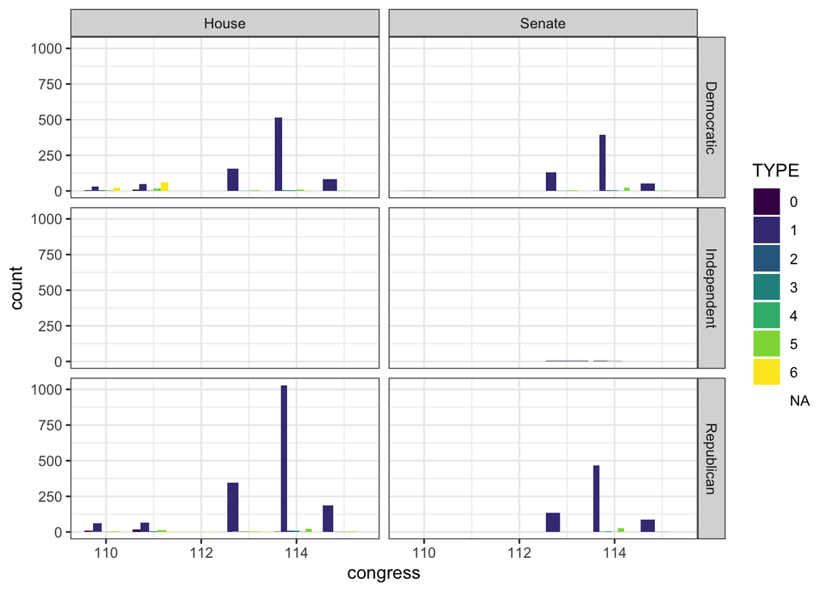

```r
#
# # d %>%   filter(str_detect(SUBJECT, "forwards")) %>% add_count(bioname, sort = T) %>% top_n(1, n) %>% select(bioname, SUBJECT) %>% kable(caption = "Letters from the legislator who forwards the most letters")
#

d %>%
  ggplot() +
  aes(x = congress, fill = TYPE) +
  geom_bar(position = "dodge") +
  facet_grid(party_name ~ chamber)
```

###Senators and Veteran Population ###HELP WITH THIS #Representative per district??

```r
vet_states <- read.csv(here("vetpop2010.csv"))
#vet_states <- read.csv("DOD Fatima (Independent Study)/vetpop2010.csv")
vet_states$state %<>% tolower()
vet_states$vetpop2010 <- gsub(",","",vet_states$vetpop2010)
vet_states$vetpop2010 %<>% as.numeric()
#write.csv(vet_states, "DOD Fatima (Independent Study)/vetpop2010.csv")

vet_states %<>% select(state, vetpop2010)
d %<>% left_join(vet_states)
```

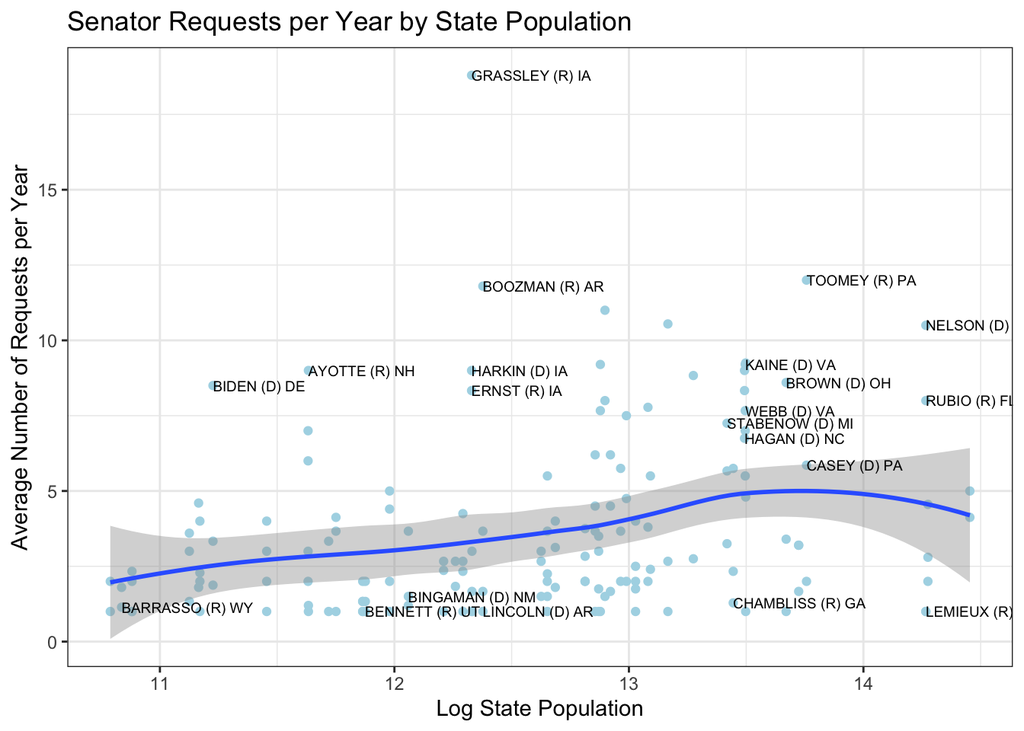

```r
d %>%
  filter(chamber == "Senate") %>%
    group_by(member_state, year, vetpop2010) %>% summarise(n = n()) %>%
    group_by(member_state, vetpop2010) %>% summarise(mean = mean(n)) %>% ungroup() %>%
  ggplot() +
    geom_point(aes(x = log(vetpop2010), y = mean), color = "light blue") +
  geom_smooth(aes(x = log(vetpop2010), y = mean)) +
  geom_text(aes(x = log(vetpop2010),
                y = mean,
                label = ifelse(mean > mean(mean)*1.5 | mean < mean(mean)*0.5,
                               member_state, "")),
            check_overlap = TRUE,
            size = 2.5,
            hjust = 0) +
  theme_bw() +
  labs(title = "Senator Requests per Year by State Population",
       x = "Log State Population",
       y = "Average Number of Requests per Year")
```

```r
Chamber = "Senate"

d %>%
  ungroup() %>%
  filter(chamber == Chamber) %>%
  group_by(state) %>% summarise(n = n()) %>%
# map_id creates the aesthetic mapping to the state name column
ggplot() +
  # map points to the fifty_states shape data
  geom_map(aes(map_id = state, fill = n), map = fifty_states) +
  expand_limits(x = fifty_states$long, y = fifty_states$lat) +
  coord_map() +
  scale_x_continuous(breaks = NULL) +
  scale_y_continuous(breaks = NULL) +
  labs(x = "", y = "", title = paste("Total Number of Contacts from members of the", Chamber)) +
  scale_fill_viridis_c(option = "C", end = .8) +
  theme(legend.position = "bottom", legend.title = element_blank(),
        panel.background = element_blank()) # + facet_grid(. ~ Constituent)
```

[output not shown]

```r
Chamber = "Senate"

d %>%
  ungroup() %>%
  filter(chamber == Chamber) %>%
  group_by(state) %>% summarise(n = n()) %>%
# map_id creates the aesthetic mapping to the state name column
ggplot() +
  # map points to the fifty_states shape data
  geom_map(aes(map_id = state, fill = n), map = fifty_states) +
  expand_limits(x = fifty_states$long, y = fifty_states$lat) +
  coord_map() +
  scale_x_continuous(breaks = NULL) +
  scale_y_continuous(breaks = NULL) +
  labs(x = "", y = "", title = paste("Total Number of Contacts from members of the", Chamber)) +
  scale_fill_viridis_c(option = "C", end = .8) +
  theme(legend.position = "bottom", legend.title = element_blank(),
        panel.background = element_blank()) # + facet_grid(. ~ Constituent)
```

[output not shown]

### Senators vs. state population

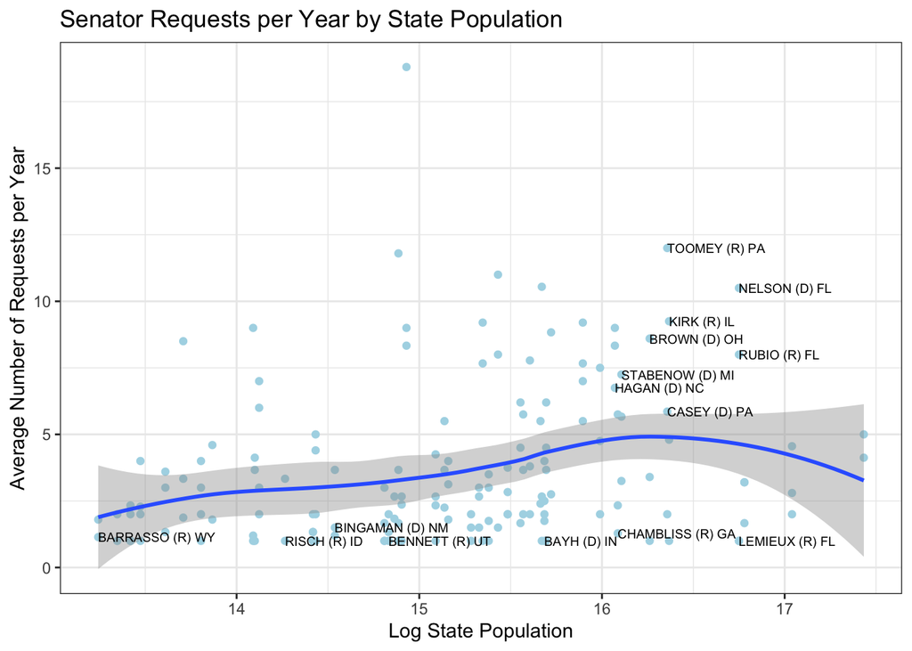

```r
d %>%
  filter(chamber == "Senate") %>%
    group_by(member_state, year, pop2010) %>% summarise(n = n()) %>%
    group_by(member_state, pop2010) %>% summarise(mean = mean(n)) %>% ungroup() %>%
    ggplot() +
    geom_point(aes(x = log(pop2010), y = mean), color = "light blue") +
  geom_smooth(aes(x = log(pop2010), y = mean)) +
  geom_text(aes(x = log(pop2010),
                y = mean,
                label = ifelse(mean > mean(mean)*1.5 | mean < mean(mean)*0.5,
                               member_state, "")),
            check_overlap = TRUE,
            size = 2.5,
            hjust = 0) +
  theme_bw() +
  labs(title = "Senator Requests per Year by State Population",
       x = "Log State Population",
       y = "Average Number of Requests per Year")
```

```r
Chamber = "Senate"

d %>%
  ungroup() %>%
  filter(chamber == Chamber) %>%
  group_by(state) %>% summarise(n = n()) %>%
# map_id creates the aesthetic mapping to the state name column
ggplot() +
  # map points to the fifty_states shape data
  geom_map(aes(map_id = state, fill = n), map = fifty_states) +
  expand_limits(x = fifty_states$long, y = fifty_states$lat) +
  coord_map() +
  scale_x_continuous(breaks = NULL) +
  scale_y_continuous(breaks = NULL) +
  labs(x = "", y = "", title = paste("Total Number of Contacts from members of the", Chamber)) +
  scale_fill_viridis_c(option = "C", end = .8) +
  theme(legend.position = "bottom", legend.title = element_blank(),
        panel.background = element_blank()) # + facet_grid(. ~ Constituent)
```

[output not shown]

```r
##What on earth is happening here?

# d %>%
#   ungroup() %>%
#   filter(chamber == Chamber) %>%
#   group_by(state, pop2010) %>% summarise(n = n()) %>% ungroup() %>%
#   mutate(Per_Capita = n/pop2010*1000000) %>%
#   # map_id creates the aesthetic mapping to the state name column in your data
#   ggplot() +
#   # map points to the fifty_states shape data
#   geom_map(aes(map_id = state, fill = Per_Capita), map = fifty_states) +
#   expand_limits(x = fifty_states$long, y = fifty_states$lat) +
#   coord_map() +
#   scale_x_continuous(breaks = NULL) +
#   scale_y_continuous(breaks = NULL) +
#   labs(x = "", y = "", title = paste("Contacts Per hundred thousand Residents from Members of the", Chamber)) +
#   scale_fill_viridis_c(option = "C", end = .8) +
#   theme(legend.position = "bottom",
#         legend.title = element_blank() )#+facet_grid(. ~ Constituent)
#
# ##Copy. Add constitutent for type 1
#
# d  %>%
#   mutate(Per_Capita = (pop2010)*1000000) %>% ##FIXME non-numeric argument to binary operator
#   # map_id creates the aesthetic mapping to the state name column in your data
#   ggplot() +
#   # map points to the fifty_states shape data
#   geom_map(aes(map_id = state, fill = Per_Capita), map = fifty_states) +
#   expand_limits(x = fifty_states$long, y = fifty_states$lat) +
#   coord_map() +
#   scale_x_continuous(breaks = NULL) +
#   scale_y_continuous(breaks = NULL) +
#   labs(x = "", y = "", title = paste("Contacts Per hundred thousand Residents from Members of the", Chamber)) +
#   scale_fill_viridis_c(option = "C", end = .8) +
#   theme(legend.position = "bottom",
#         legend.title = element_blank() )+
#   facet_grid(. ~ Constituent)
```

##House Contacts per State ##Contacts per district ##Would this be relevannt??

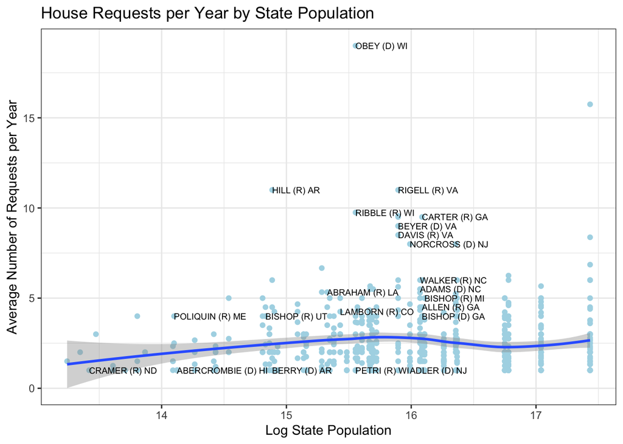

```r
d %>%
  filter(chamber == "House") %>%
    group_by(member_state, year, pop2010) %>% summarise(n = n()) %>%
    group_by(member_state, pop2010) %>% summarise(mean = mean(n)) %>% ungroup() %>%
    ggplot() +
    geom_point(aes(x = log(pop2010), y = mean), color = "light blue") +
  geom_smooth(aes(x = log(pop2010), y = mean)) +
  geom_text(aes(x = log(pop2010),
                y = mean,
                label = ifelse(mean > mean(mean)*1.5 | mean < mean(mean)*0.5,
                               member_state, "")),
            check_overlap = TRUE,
            size = 2.5,
            hjust = 0) +
  theme_bw() +
  labs(title = "House Requests per Year by State Population",
       x = "Log State Population",
       y = "Average Number of Requests per Year")
```

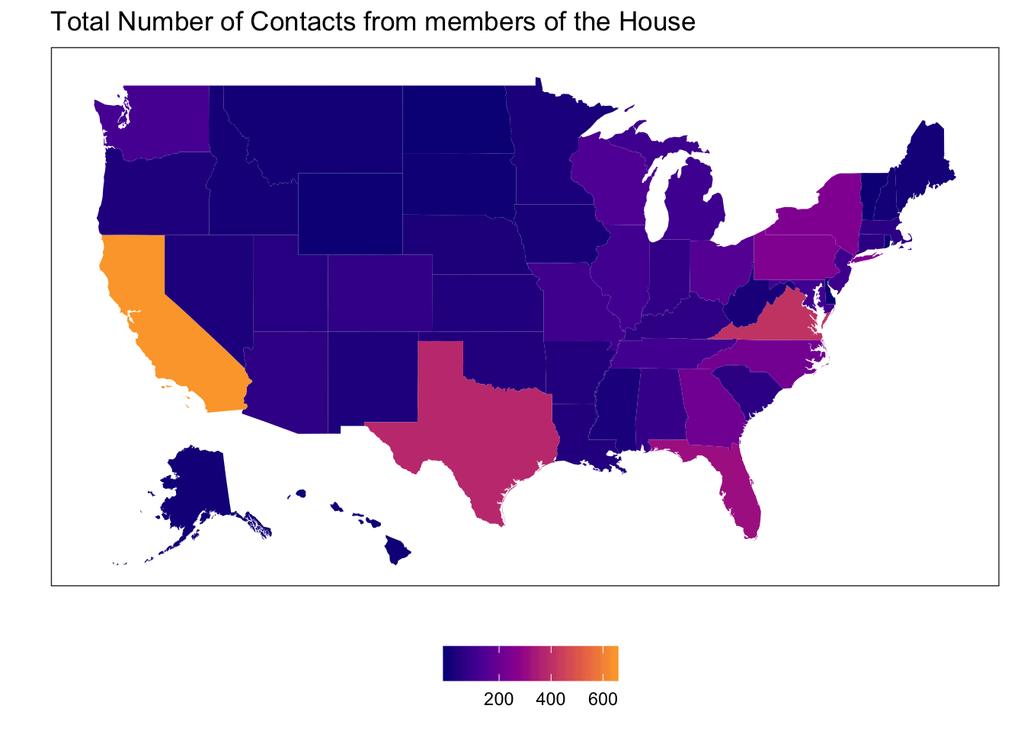

```r
Chamber = "House"

d %>%
  ungroup() %>%
  filter(chamber == Chamber) %>%
  group_by(state) %>% summarise(n = n()) %>%
# map_id creates the aesthetic mapping to the state name column
ggplot() +
  # map points to the fifty_states shape data
  geom_map(aes(map_id = state, fill = n), map = fifty_states) +
  expand_limits(x = fifty_states$long, y = fifty_states$lat) +
  coord_map() +
  scale_x_continuous(breaks = NULL) +
  scale_y_continuous(breaks = NULL) +
  labs(x = "", y = "", title = paste("Total Number of Contacts from members of the", Chamber)) +
  scale_fill_viridis_c(option = "C", end = .8) +
  theme(legend.position = "bottom", legend.title = element_blank(),
        panel.background = element_blank()) # + facet_grid(. ~ Constituent)
```

### Members who contact DOD more than average:

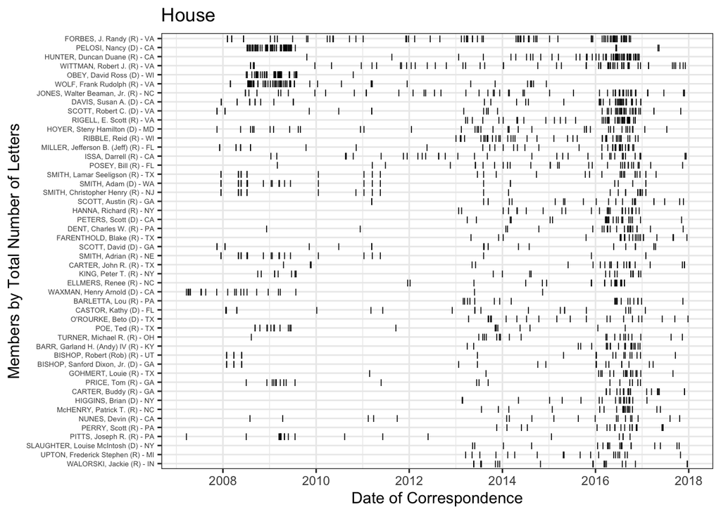

```r
# barcode plot of committee members

# member by year by agency
d %>%
  filter(chamber == Chamber) %>%
  group_by(name_state) %>% mutate(n = n()) %>% ungroup() %>%
  filter(n > mean(n)) %>%
  ggplot() +
  geom_point(
    aes(x = DATE,
        y = reorder(name_state, n) ),
    # alpha = .6,
    shape = 73,
    size=2
  ) +
  labs(title = paste(Chamber),
       y = paste("Members by", "Total Number of Letters"),
       x = "Date of Correspondence" ) +
  theme(
    legend.title = element_blank(),
    axis.text.y = element_text(size=5)
  ) +
    guides(fill=guide_legend(ncol=1))
```

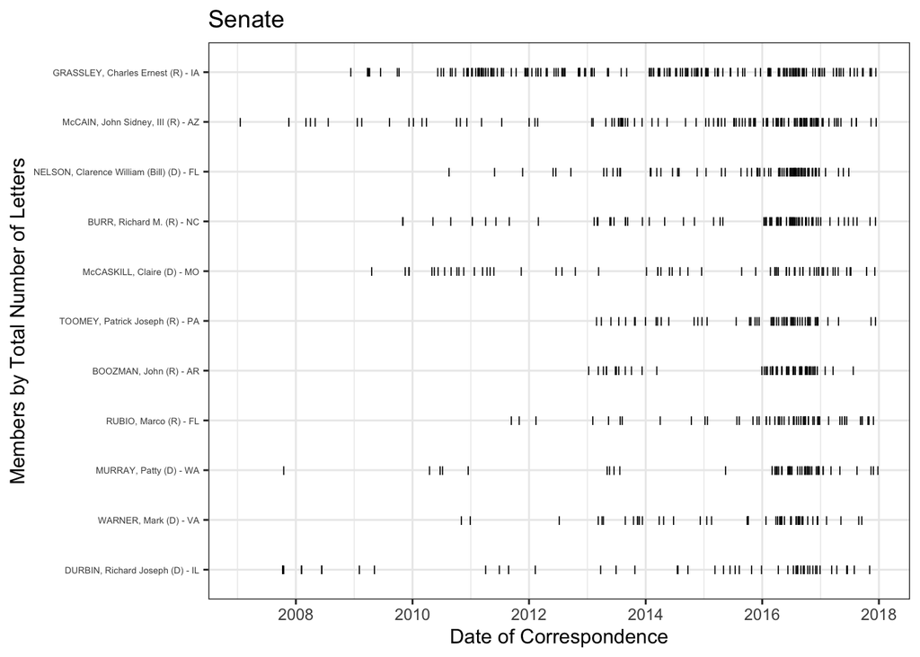

```r
Chamber <- "Senate" # "Senate"

# member by year by agency
d %>%
  filter(chamber == Chamber) %>%
  group_by(name_state) %>% mutate(n = n()) %>% ungroup() %>%
  filter(n > mean(n)) %>%
  ggplot() +
  geom_point(
    aes(x = DATE,
        y = reorder(name_state, n) ),
    # alpha = .6,
    shape = 73,
    size=2
  ) +
  labs(title = paste(Chamber),
       y = paste("Members by", "Total Number of Letters"),
       x = "Date of Correspondence" ) +
  theme(
    legend.title = element_blank(),
    axis.text.y = element_text(size=5)
  ) +
    guides(fill=guide_legend(ncol=1))
```

```r
# all_contacts %>%
#   filter(congress >109) %>%
#   mutate(DOD = agency == "DOD_OSDJS") %>%
#   count(chamber, OSDJS, name_state, state) %>%
#   spread(key = "OSDJS", value = "n", 0) %>%
#   mutate(ShareToOSDJS = round(`TRUE`/(`TRUE`+`FALSE`),2) ) %>%
#   arrange(-ShareToOSDJS) %>%
#   mutate(total = `TRUE` + `FALSE`) %>%
#   select(name_state, chamber, total, ShareToFERC) %>%
#   filter(ShareToOSDJS>.3) %>%
#   knitr::kable(caption = "Members who contact FERC more, relative to other agencies" )
#
#
# # facet on agency, how does it differ across agencies
#
# chamber <- "Senate" # "Senate" #why does it say False?
#
# all_contacts %>%
#   filter(chamber == "Senate") %>%
#   #filter(str_detect(agency, "DOD")) %>%
#   mutate(DOD = agency == "DOD_OSDJS") %>%
#   group_by(chamber, Department, name_state, state) %>%
#   summarise(n = n() ) %>%
#   ungroup() %>%
#   #spread(key = "DOD", value = n) %>%
#   top_n(10, n) %>%
#   knitr::kable()
#
#   # mutate(ShareToDOD = round(`TRUE`/(`TRUE`+`FALSE`),2) ) %>%
#   # arrange(-ShareToDOD) %>%
#   # mutate(total = `TRUE` + `FALSE`) %>%
#   # select(name_state, chamber, total, ShareToDOD) %>%
#   # filter(ShareToDOD>.3) %>%
#
#
# chamber <- "House"
#
# all_contacts %>%
#   filter(chamber == "House") %>%  #why is this working this way??
#   mutate(DOD = agency == "DOD$") %>%
#   group_by(chamber, DOD, name_state, state) %>%
#   summarise(n = n() ) %>%
#   ungroup() %>%
#   #spread(key = "DOD", value = n) %>%
#   top_n(10, n) %>%
#   knitr::kable()
#
#  ## Members who contact FERC more in a Congress, relative to other agencies
```

#A rough under-estimate based on whether “et al” or “&” appears in the summary: # INVESTIGATE

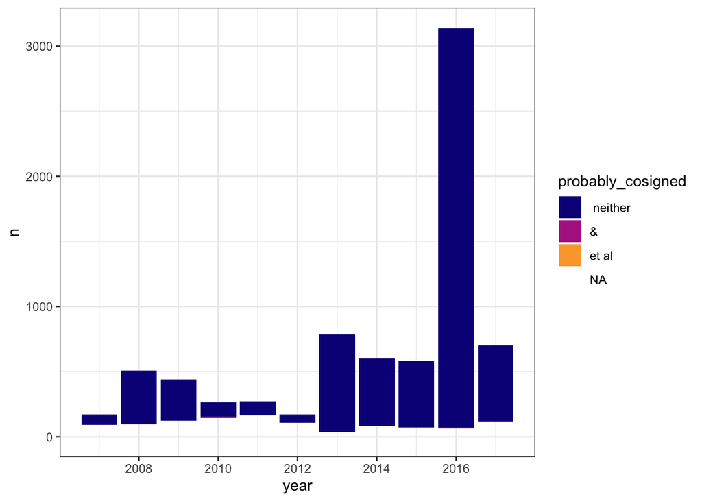

```r
d %>%
  group_by(ID) %>%
  mutate(probably_cosigned = ifelse(str_detect(SUBJECT, "et al"), "et al",
                                 ifelse(str_detect(SUBJECT, "&"), "&", " neither"))) %>%
  group_by(year, probably_cosigned) %>%
  tally %>%
  ggplot() +
  aes(x = year, y = n, fill = probably_cosigned) +
  geom_col() +
  scale_fill_viridis_d(option = "C", end = .8)
```

##How to fix this committee Code

#Left join committees into all_contacts #Group by ICPSR and Congress #Summarize committees = paste committee #Full join of all contacts and committees, larger data set

# Modify committees variable, ICPSR, Congress, Committee= Armed Services

```r
# d %>%
#   mutate(chair = str_remove(chair,"[0-9]* |^NA "),
#          committee = paste(chamber, committees))%>%
#   dplyr::select(committee, position, chair, DATE, assigneddate, terminationdate) %>%
#   distinct() %>%
#   filter(str_detect(committee, "ENERGY$|ENVIRONMENT|NATURAL")) %>%
#   mutate(position = ifelse(position == "Other", NA, position)) %>%
#   #filter(# !is.na(position),chair_since_2007 == T) %>%
#   drop_na(chair) %>%
#   dplyr::select(DATE, chair, position, assigneddate, terminationdate, committee) %>%
#   distinct() %>%
#   ggplot() +
#   geom_point(
#     aes(x = DATE,
#         y = chair),
#     shape = 73,
#     size=2
#   ) +
#   geom_segment(aes(y = chair, yend = chair,
#                    x = date, xend = date,
#                    linetype = factor(position)),
#                position = position_nudge(y = -0.3)) +
#   labs(title = paste("Letters to FERC from Committee Leadership"),
#        y = "",
#        x = "",
#        linetype = "Leadership position") +
#   scale_y_discrete(position = "right") +
#   theme(
#     strip.text.y = element_text(angle = 180, size = 5),
#     # legend.title = element_blank(),
#     axis.text.y = element_text(size=5),
#     axis.text.x = element_text(angle = 0)
#   ) +
#   facet_grid(committee ~ ., scales = "free_y", space = "free_y", switch = "both")
```

```r
# MEMBER DEMOGRAPHICS


# gender for those where we have the data from LEP # WE HAVE BETTER DATA, NEEDS TO BE MERGED IN
d %<>%
  # merge LEP data into df
  left_join(
    # read in the LEP data
    read.csv(here("members/LEP111to113.csv")) %>%
      # just grabbing female variable for now
      select(icpsr, female) %>%
      # distinct icpsr-gender combinations
      distinct() %>%
      #make ICPSR numbers numeric to merge with df
      mutate(icpsr = as.numeric(icpsr))
  )
```

# Limitations throughout the Independent Study

# Future ideas to explore with this paper

# References

Costa, Mia (2020). Citizen Evaluations of Legislator–Constituent Communication.  
*British Journal of Political Science*.

Fenno, Richard F. (1977). U.S. House Members in Their Constituencies: An Exploration. *American Political Science Review*, 883-917.

Fenno, Richard F. (2013). *The Challenge of Congressional Representation.* Harvard  
University Press, 138-184.

Jordan, Amos A, William J. Taylor, Jr, and Michael J. Mazar (2009). American  
National Security, Johns Hopkins University Press.

Judge-Lord, Devin, Eleanor Neff Powell, and Justin Grimmer (2020). Campaign  
Contributions and Bureaucratic Oversight: A Case Study of the Federal Energy  
Regulatory Commission. Unpublished Working Paper. Presented at the Accountability and Public Policy Conference 2019.

Kingdon, John W (1977). Models of Legislative Voting. *The Journal of Politics (39)*, 563–595.

Laurance, Edward J (1976). The Changing Role of Congress in Defense Policy-Making. *The Journal of Conflict Resolution (20)*, 213–253.

Lindsay, James M., and Randall B. Ripley (1992). Foreign and Defense Policy in Congress: A Research Agenda for the 1990s. *Legislative Studies Quarterly*, 417–449.

Lindsay, James M., and Randall B. Ripley (1994). How Congress Influences Foreign and Defense Policy. *Bulletin of the American Academy of Arts and Sciences, 47*, 7–32.

Lowande, Kenneth (2018). Politicization and Responsiveness in Executive Agencies.  
*Journal of Politics*.

Lowande, Kenneth (2018). Who Polices the Administrative State? American Political  
Science Review, 874–890.

McCarty, Nolan, Keith T. Poole, and Howard Rosenthal (2006). *Polarized America: The dance of ideology and unequal riches*, MIT Press.

Oleszek, Walter J (2013). *Congressional Procedures and the Policy Process*,  
Congressional Quarterly Press.

Poole, Keith T. and Howard Rosenthal (2007) *Ideology and Congress*, Transaction  
Publishers.

Powell, Eleanor Neff and Justin Grimmer (2016). Money in Exile: Campaign Contributions and Committee Access. *The Journal of Politics 78(4)*, 974–88.

Reif, Kingston (2017). Congress Rewrites Missile Defense Policy. *Arms Control Today, 47*, 40–42.

Ritchie, Melinda N (2017). Back-Channel Representation: A Study of the Strategic Communication of Senators with the US Department of Labor. *Journal of Politics*.

Ritchie, M.N. and You, H.Y (2019). Legislators as Lobbyists. Legislative Studies  
Quarterly, 65-95.

Rohde, David W (1991). *Parties and leaders in the post-reform House of Representatives.* University of Chicago Press.

US Census Bureau (2018). Veterans Statistics. *The United States Census Bureau*.  
https://www.census.gov/library/visualizations/2015/comm/veterans-statistics.html. Date accessed: February 14, 2020.

# Notes:

1. Count letters by member by year (including zero counts)
2. Policy Stuff
3. Divide by years–annualized by years
4. Control with Gender–how long they’re in congress
5. Veterans–More likely to write, shared Veteran status. Veterans-gender-bias
6. What Kind of Variate Models??–Pro-business/anti-business/Constituent vs. everyone else/ Party Explanatory #Party # constituent vs non constituent
7. Electoral Interests?–how to measure that? #Most important issue data #State